# Capsule 2 - Lissage exponentiel simple

MQT-2101 - Analyse et modélisation des données

## Pourquoi ça compte

Les observations récentes peuvent compter davantage sans effacer tout l’historique.

Quel rôle joue le paramètre alpha?

Le lissage exponentiel met à jour un niveau estimé en pondérant la dernière observation et le niveau précédent.

## Objectifs de la capsule

- Expliquer le rôle de alpha.
- Choisir le lissage simple seulement lorsque sa structure est plausible.
- Distinguer estimation du paramètre et évaluation du modèle.

## Alpha est estimé avant d’être évalué

- Un alpha élevé réagit plus vite.
- Un alpha faible produit un niveau plus stable.
- Le lissage simple n’est pas adapté à une forte tendance non modélisée.

## Ajuster le lissage sur l’entraînement

```r
fit <- forecast::ses(serie, h = horizon)
autoplot(fit) +
  labs(x = "Semaine", y = "Demande (unités)") +
  theme_minimal(base_size = 14)
```

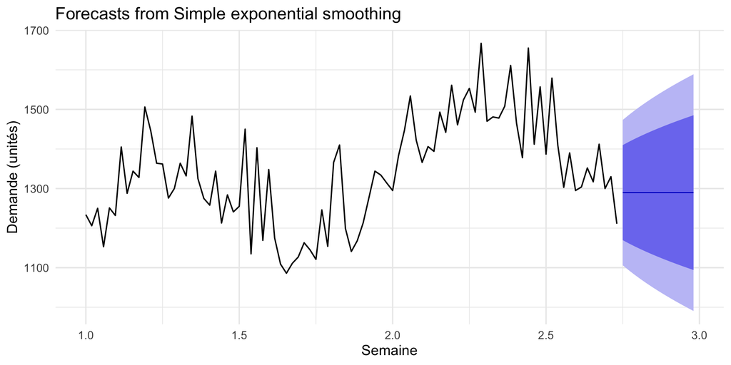

## Estimer les paramètres, puis comparer les méthodes

Alpha est estimé sur l’apprentissage. Les méthodes candidates sont comparées sur la validation. Un test final distinct ne sert pas à retoucher le choix.

## Prolongement : Holt ajoute une pente

$$\widehat y_{t+h\mid t}=\ell_t+h b_t$$

- $\ell_t$ : niveau estimé; $b_t$ : pente estimée.
- Deux états mis à jour avec les observations passées.
- Aucune saisonnalité explicite.

## Amortir la tendance à mesure que l’horizon augmente

$$\widehat y_{t+h\mid t}=\ell_t+(\phi+\cdots+\phi^h)b_t,\quad 0<\phi<1$$

`holt(serie, h = horizon, damped = TRUE)` estime les paramètres sur l’apprentissage. Le code est fourni; le calcul manuel des récurrences n’est pas demandé.

## À retenir

1

Le niveau lissé est une prévision révisable.

2

La méthode doit être comparée à une référence.

3

La décision reste liée aux données disponibles.

## Production autonome 7.2

Comparez qualitativement les effets de alpha = 0,2 et alpha = 0,8 pour une demande récente en hausse.

### Auto-vérification

- Toutes les méthodes utilisent la même période de validation.
- J’ai interprété l’erreur dans son unité.
- J’ai relié le résultat à une décision et à une limite.